# Prueba Adriana Castillo

Se buscar encontrar la eficiencia de la generación de números pseudo-aletorios a través de los métodos de cuadrados medios y congruencia lineal, para ello se debe seguir el siguiente proceso:

1. A traves de la misma api generar una semilla diferente.
2. Encontrar el numero de iteraciones hasta que se repita uno de sus datos.
3. Generar 100 simulaciones con diferentes semillas.
4. Generar un histograma con el resultado obtenidos por cada método.
5. Agregar sus conclusiones, opiniones y recomendaciones

## Método de cuadrados medios

1. A traves de la misma api generar una semilla diferente.

```python
import pandas as pd, math
cuadrados={}
repetidos=[]
unicos=[]
iteraciones_s = 100
semilla_s = 910932#1029 #int(input ("Semilla: "))
digitos_s = 4

val_xn_s=[]
val_xn_m_s=[]
val_ui_semillas=[]
val_rn_s=[]
div_s=[int(str(num).ljust(digitos_s+1, "0")) for num in [1]]
ui_s=""
izq_s=int(digitos_s/2)
der_s=digitos_s-izq_s

for i in range(iteraciones_s):
    if(len(str(semilla_s))>=3):
        if(len(str(semilla_s*semilla_s))>digitos_s):
            val_xn_s.append(semilla_s)
            val_xn_m_s.append(semilla_s*semilla_s)
            numero_s = str(semilla_s*semilla_s)
            mitad_s=math.floor(len(numero_s)/2)
            if(int(numero_s)>0):
                for p in range(mitad_s-izq_s, mitad_s+der_s, 1): ui_s+=numero_s[p]
            val_ui_semillas.append(ui_s)
            val_rn_s.append(int(ui_s)/div_s[0])
            semilla_s=int(val_ui_semillas[-1])
            ui_s=''
        else:
            print('\n* Número de dígitos es muy alto')
            break
    else:
        print('\n* * La semilla debe ser mayor a 0 y de 3 dígitos')
        break

print('Semillas generadas: \n',val_ui_semillas)
```

```
Semillas generadas:
 ['9710', '2841', '0712', '0694', '8163', '6345', '2590', '7081', '1405', '9740', '8676', '2729', '4474', '0166', '2755', '5900', '8100', '6100', '2100', '4100', '8100', '6100', '2100', '4100', '8100', '6100', '2100', '4100', '8100', '6100', '2100', '4100', '8100', '6100', '2100', '4100', '8100', '6…
```

1. Encontrar el numero de iteraciones hasta que se repita uno de sus datos.

```python
def cuadrados_medios(semilla):
    rep=1
    iteraciones = 1000
    digitos = 4
    val_xn=[]
    val_xn_m=[]
    val_ui=[]
    val_rn=[]
    div=[int(str(num).ljust(digitos+1, "0")) for num in [1]]
    ui=""
    izq=int(digitos/2)
    der=digitos-izq

    for i in range(iteraciones):
        val_xn.append(semilla)
        val_xn_m.append(semilla*semilla)
        numero = str(semilla*semilla)
        mitad=math.floor(len(numero)/2)
        for p in range(mitad-izq, mitad+der, 1): ui+=numero[p]
        if ui in val_ui:
            #print('Repetido', ui, ' pos: ',rep)
            cuadrados[rep] = cuadrados[rep] + 1 if rep in cuadrados else  1
            break
        unicos.append(ui)
        val_ui.append(ui)
        val_rn.append(int(ui)/div[0])
        semilla=int(val_ui[-1])
        ui=''
        rep+=1
        #print(val_ui)
```

1. Generar 100 simulaciones con diferentes semillas.

```python
cuadrados={}
for x in val_ui_semillas:
    #print(' ',ite,'º --> Semilla:', x)
    #ite+=1
    cuadrados_medios(int(x))

print(cuadrados)
```

```
{20: 1, 19: 1, 18: 1, 17: 1, 16: 1, 15: 1, 14: 1, 13: 1, 12: 1, 11: 1, 10: 1, 9: 1, 8: 1, 7: 1, 6: 1, 5: 85}
```

1. Generar un histograma con el resultado.

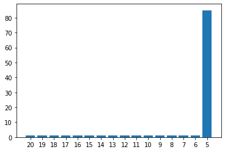

```python
import matplotlib.pyplot as plt

D = cuadrados
plt.bar(range(len(D)), list(D.values()), align='center')
plt.xticks(range(len(D)), list(D.keys()))
plt.show()
```

## Método de congruencias lineales

1. A traves de la misma api generar una semilla diferente.

```python
import pandas as pd, math
congruencias={}
iteraciones_cl =100
semilla_cl= 1 ##Semilla inicial
a_cl=3
b_cl=5
m_cl=19
val_xn_cl=[semilla_cl]
val_un_cl=['']

for i in range(iteraciones_cl): val_xn_cl.append((a_cl*val_xn_cl[-1]+b_cl)%m_cl) ; val_un_cl.append(val_xn_cl[-1]/m_cl)

print('Semillas generadas: \n',val_xn_cl)
```

```
Semillas generadas:
 [1, 8, 10, 16, 15, 12, 3, 14, 9, 13, 6, 4, 17, 18, 2, 11, 0, 5, 1, 8, 10, 16, 15, 12, 3, 14, 9, 13, 6, 4, 17, 18, 2, 11, 0, 5, 1, 8, 10, 16, 15, 12, 3, 14, 9, 13, 6, 4, 17, 18, 2, 11, 0, 5, 1, 8, 10, 16, 15, 12, 3, 14, 9, 13, 6, 4, 17, 18, 2, 11, 0, 5, 1, 8, 10, 16, 15, 12, 3, 14, 9, 13, 6, 4, 17, …
```

1. Encontrar el numero de iteraciones hasta que se repita uno de sus datos.

```python
def congurencias_lineales(semillas):
    semilla=semillas
    rep_c=1
    iteraciones = 1000
    a=3
    b=9
    m=5
    val_xn=[semilla]
    val_un=['']

    for i in range(iteraciones):
        xn=(a*val_xn[-1]+b)%m
        if xn in val_xn:
            congruencias[rep_c] = congruencias[rep_c] + 1 if rep_c in congruencias else  1
            break

        val_xn.append(xn)
        val_un.append(val_xn[-1]/m)
        rep_c+=1
    #print(val_xn)
```

1. Generar 100 simulaciones con diferentes semillas.

```python
for x in val_xn_cl:
    congurencias_lineales(int(x))
print(congruencias)
```

```
{4: 21, 2: 17, 5: 57, 1: 6}
```

1. Generar un histograma con el resultado.

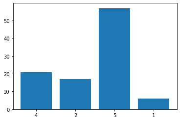

```python
import matplotlib.pyplot as plt

D = congruencias
plt.bar(range(len(D)), list(D.values()), align='center')
plt.xticks(range(len(D)), list(D.keys()))
plt.show()
```

# Conclusiones, opiniones y recomendaciones

Como conclusión podemos observar que en el metodo de cuadrados medios en la iteración 5 ocurre el mayor numero de repeticiones y en las demas solo se repite una vez, mientras que en el metodo de congruencia lineal donde aparecen las repeticiones va variando y no unicamente en la iteración número 5.

Como recomendación se debe tener en cuenta la semilla inicial que se escoja para que no se repitan las semillas generadas para las iteraciones.